# InVivoStat Logistic Regression Analysis

## Response and covariate

The Response1a response is currently being analysed by the Logistic Regression Analysis module, with Covariate1 and Covariate2 fitted as covariates.The covariates have been Square Root transformed prior to analysis.

## Analysis of deviance table

| Effect | Degrees of freedom | Chi-square | p-value |
| --- | --- | --- | --- |
| (Intercept) | 1 | 7.705 | 0.0055 |
| Covariate1 | 1 | 1.090 | 0.2964 |
| Covariate2 | 1 | 1.134 | 0.2869 |
| Cont1 | 1 | 20.680 | < 0.0001 |
| Cont2 | 1 | 0.040 | 0.8411 |
| Cont3 | 1 | 1.491 | 0.2220 |
| Cat1 | 1 | 1.192 | 0.2749 |
| Cat&2 | 2 | 1.739 | 0.4192 |
| Cat$3 | 2 | 0.983 | 0.6117 |
| Cat1 * Cat&2 | 2 | 4.323 | 0.1152 |
| Cat1 * Cat$3 | 2 | 1.095 | 0.5784 |
| Cat&2 * Cat$3 | 4 | 3.874 | 0.4233 |
| Cat1 * Cat&2 * Cat$3 | 4 | 2.452 | 0.6532 |

Comment: Analysis of deviance table calculated using a Type III model fit, see Armitage et al. (2001).

Conclusion: There is a statistically significant overall difference between the levels of (Intercept), Cont1.

## Plot of model predictions

This option is only available if the model contains a single continuous factor.

## Odds ratio

| Parameter | Odds ratio | Lower 95% CI | Upper 95% CI |
| --- | --- | --- | --- |
| Covariate1 | 0.23 | 0.014 | 3.70 |
| Covariate2 | 0.27 | 0.022 | 2.96 |
| Cont1 | 0.57 | 0.434 | 0.71 |
| Cont2 | 0.96 | 0.665 | 1.40 |
| Cont3 | 0.57 | 0.190 | 1.23 |
| Cat11 | 0.77 | 0.472 | 1.22 |
| Cat&21 | 1.04 | 0.533 | 2.05 |
| Cat&22 | 1.46 | 0.675 | 3.20 |
| Cat$31 | 1.43 | 0.707 | 3.00 |
| Cat$32 | 0.80 | 0.348 | 1.82 |
| Cat11:Cat&21 | 1.58 | 0.821 | 3.12 |
| Cat11:Cat&22 | 0.45 | 0.205 | 0.93 |
| Cat11:Cat$31 | 1.45 | 0.661 | 3.74 |
| Cat11:Cat$32 | 1.12 | 0.564 | 2.22 |
| Cat&21:Cat$31 | 2.19 | 0.850 | 6.29 |
| Cat&22:Cat$31 | 0.68 | 0.240 | 1.85 |
| Cat&21:Cat$32 | 1.05 | 0.391 | 2.95 |
| Cat&22:Cat$32 | 0.98 | 0.297 | 3.01 |
| Cat11:Cat&21:Cat$31 | 0.71 | 0.259 | 1.83 |
| Cat11:Cat&22:Cat$31 | 1.12 | 0.390 | 3.23 |
| Cat11:Cat&21:Cat$32 | 1.46 | 0.574 | 3.94 |
| Cat11:Cat&22:Cat$32 | 0.49 | 0.138 | 1.53 |

Note: Confidence intervals are based on the profiled log-likelihood function.

To interpret these results: For a one-unit increase in the parameter, the odds ratio (given as a fold-change) indicates the corresponding increase/decrease in the probability that the response gives a 'positive result'.

## Model prediction assessment

|  | Predicted response = 4 | Predicted response = -1 |
| --- | --- | --- |
| Observed level = 4 | 47 | 15 |
| Observed level = -1 | 16 | 44 |

The model correctly classifies the responses in 74.59% of the time.

## Model predictions

| Observation number | Response1a | Cont1 | Cont2 | Cont3 | Cat1 | Cat&2 | Cat$3 | Covariate1 | Covariate2 | scatterPlotColumn | Prediction |
| --- | --- | --- | --- | --- | --- | --- | --- | --- | --- | --- | --- |
| 1 | -1 | 1 | 1 | 1 | q | e | i | 0.41 | 0.617 | q e i | 0.983 |
| 2 | -1 | 2 | 2 | 2 | q | e | o | 0.75 | 0.577 | q e o | 0.659 |
| 3 | -1 | 3 | 3 | 3 | q | e | u | 0.46 | 0.698 | q e u | 0.492 |
| 4 | -1 | 4 | 4 | 1 | q | e | i | 0.65 | 0.753 | q e i | 0.846 |
| 5 | 4 | 5 | 1 | 2 | q | e | o | 0.73 | 0.842 | q e o | 0.211 |
| 6 | 4 | 6 | 2 | 3 | q | e | u | 0.44 | 0.747 | q e u | 0.152 |
| 7 | 4 | 7 | 3 | 1 | q | e | i | 0.51 | 0.483 | q e i | 0.645 |
| 8 | 4 | 8 | 4 | 2 | q | e | o | 0.61 | 0.952 | q e o | 0.043 |
| 9 | -1 | 1 | 1 | 3 | q | e | u | 0.28 | 0.497 | q e u | 0.845 |
| 10 | -1 | 2 | 2 | 1 | q | e | i | 0.73 | 0.769 | q e i | 0.941 |
| 11 | 4 | 3 | 3 | 2 | q | e | o | 0.87 | 0.415 | q e o | 0.522 |
| 12 | 4 | 4 | 4 | 3 | q | e | u | 0.52 | 0.675 | q e u | 0.333 |
| 13 | 4 | 5 | 5 | 1 | q | y | i | 0.16 | 0.938 | q y i | 0.371 |
| 14 | 4 | 6 | 1 | 2 | q | y | o | 0.62 | 0.038 | q y o | 0.265 |
| 15 | 4 | 7 | 2 | 3 | q | y | u | 0.73 | 0.772 | q y u | 0.215 |
| 16 | 4 | 8 | 3 | 1 | q | y | i | 0.68 | 0.654 | q y i | 0.073 |
| 17 | -1 | 1 | 4 | 2 | q | y | o | 0.80 | 0.797 | q y o | 0.606 |
| 18 | -1 | 2 | 1 | 3 | q | y | u | 0.80 | 0.953 | q y u | 0.773 |
| 19 | -1 | 3 | 2 | 1 | q | y | i | 0.82 | 0.750 | q y i | 0.501 |
| 20 | -1 | 4 | 3 | 2 | q | y | o | 0.51 | 0.139 | q y o | 0.513 |
| 21 | -1 | 5 | 4 | 3 | q | y | u | 0.29 | 0.659 | q y u | 0.636 |
| 22 | 4 | 6 | 1 | 4 | q | y | i | 0.38 | 0.857 | q y i | 0.055 |
| 23 | 4 | 7 | 2 | 1 | q | y | o | 0.85 | 0.518 | q y o | 0.115 |
| 24 | 4 | 8 | 3 | 2 | q | y | u | 0.34 | 0.580 | q y u | 0.375 |
| 25 | -1 | 1 | 4 | 3 | q | u | i | 0.60 | 0.786 | q u i | 0.907 |
| 26 | -1 | 2 | 5 | 4 | q | u | o | 0.59 | 0.328 | q u o | 0.931 |
| 27 | -1 | 3 | 1 | 1 | q | u | u | 0.98 | 0.574 | q u u | 0.940 |
| 28 | -1 | 4 | 2 | 2 | q | u | i | 0.87 | 0.641 | q u i | 0.733 |
| 29 | -1 | 5 | 3 | 3 | q | u | o | 0.85 | 0.559 | q u o | 0.701 |
| 30 | -1 | 6 | 4 | 4 | q | u | u | 0.31 | 0.576 | q u u | 0.560 |

[output cut: 92 more lines]

## Goodness of fit tests

### Hosmer-Lemeshow goodness of fit test

|  | Chi-sq value | Degrees of freedom | p-value |
| --- | --- | --- | --- |
| Test result | 272.47 | 22 | <0.0001 |

Conclusion: The Hosmer-Lemeshow goodness of fit test is a statistically significant at the 0.05 level (<0.0001), indicating the model does not fit well.

Note: The number of bins used in this caluclation is two more than the number of model parameters estimated.

### McFadden adjusted R-sq

|  | R-sq value | Degrees of freedom |
| --- | --- | --- |
| Test result | 0.2841 | 23 |

McFadden's Rsq (McFadden, 1974) is defined as 1-[ln(LM)/ln(L0)], where ln(LM) is the log likelihood value for the fitted model and ln(L0) is the log likelihood for the null model with only an intercept as a predictor. The measure ranges from 0 to 1, with values closer to zero indicating that the model has no predictive power.

## Receiver operating characteristic (ROC) curve

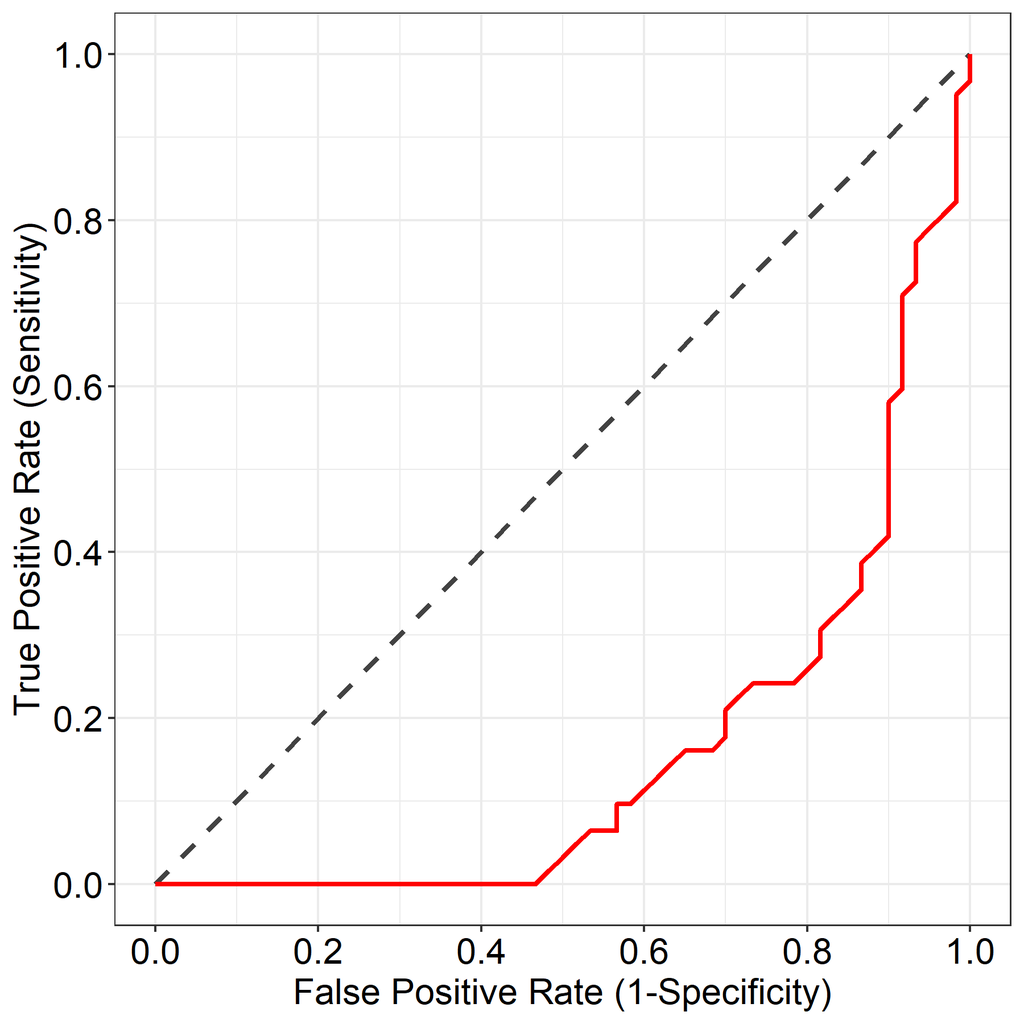

The ROC curve (Receiver Operating Characteristic) is a way to assess how good the model is at identifying (i) true positive results (or successes), measured by 'sensitivity' - the probability of predicting a true positive/success and (ii) true negative results (or failures), measured by 1-'specificity' - the probability of predicting a false positive/success. The best decision rule is high on sensitivity and low on 1-specificity. The ROC curve illustrates this.

A model that predicts no better than chance will have an ROC curve that closely follows the diagonal dotted line. The further the curve is above the diagonal line, the better the model is at discriminating between positives and negatives.

The ROC curve can also be summarised by the area under curve (AUC). The closer the AUC is to 1, the better the model is at discriminating between positives and negatives. In this case the AUC of the curve is 0.16.

## Analysis description

For more information on the theoretical approaches that are implemented within this module, see Bate and Clark (2014).

## Statistical references

Bate, S.T. and Clark, R.A. (2014). The Design and Statistical Analysis of Animal Experiments. Cambridge University Press.

McFadden, D. (1974) Conditional Logit Analysis of Qualitative Choice Behavior. In: Zarembka, P., Ed., Frontiers in Econometrics, Academic Press, 105-142.

## R references

R Development Core Team (2013). R: A language and environment for statistical computing. R Foundation for Statistical Computing, Vienna, Austria. URL http://www.R-project.org.

Barret Schloerke, Jason Crowley, Di Cook, Heike Hofmann, Hadley Wickham, Francois Briatte, Moritz Marbach and Edwin Thoen (2014). GGally: Extension to ggplot2. R package version 0.4.5. http://CRAN.R-project.org/package=GGally

Erich Neuwirth (2011). RColorBrewer: ColorBrewer palettes. R package version 1.0-5. http://CRAN.R-project.org/package=RColorBrewer

H. Wickham. ggplot2: elegant graphics for data analysis. Springer New York, 2009.

Kamil Slowikowski (2018). ggrepel: Automatically Position Non-Overlapping Text Labels with 'ggplot2'. R package version 0.8.0. https://CRAN.R-project.org/package=ggrepel

H. Wickham. Reshaping data with the reshape package. Journal of Statistical Software, 21(12), 2007.

Hadley Wickham (2011). The Split-Apply-Combine Strategy for Data Analysis. Journal of Statistical Software, 40(1), 1-29. URL http://www.jstatsoft.org/v40/i01/.

Hadley Wickham (2012). scales: Scale functions for graphics. R package version 0.2.3. http://CRAN.R-project.org/package=scales

John Fox and Sanford Weisberg (2011). An {R} Companion to Applied Regression, Second Edition. Thousand Oaks CA: Sage. URL: http://socserv.socsci.mcmaster.ca/jfox/Books/Companion

Lecoutre, Eric (2003). The R2HTML Package. R News, Vol 3. N. 3, Vienna, Austria.

Louis Kates and Thomas Petzoldt (2012). proto: Prototype object-based programming. R package version 0.3-10. http://CRAN.R-project.org/package=proto

Sing T, Sander O, Beerenwinkel N, Lengauer T (2005). ROCR: visualizing classifier performance in R. Bioinformatics, 21(20), 7881. .